# Number of cigarettes

# 1 Description of DataSchema variable

The description of harmonised variable is the following:

- Short name: `n_cigarettes`
- Variable label: `Number of cigarettes smoked per week`
- Variable description: `Number of cigarettes smoked per week. Current smokers cigarettes only`
- Domain: `Lifestyle and health behaviours`
- Value type: `continuous`
- Category missings:

| **Code** | **Category Label** |
| --- | --- |
| 991 | CAPI/interviewer error |
| 992 | Impute |
| 993 | Disable to measure |
| 994 | Not attempt/not done |
| 995 | Does not answer |
| 996 | Not applicable |
| 997 | Refuse |
| 998 | Do not know |
| 999 | Missing |

# 2 Data process

## 2.1 England

### 2.1.1 Wave 1

#### 2.1.1.1 Study-specific variable description

| **Name** | `heskb` | `heskc` |
| --- | --- | --- |
| **Label** | `About how many cigarettes a day do you usually smoke on weekdays?` | `About how many cigarettes a day do you usually smoke on weekends?` |
| **Table name** | `wave_1_core_data_v3` | `wave_1_core_data_v3` |
| **Categories:** | `continuous` | `continuous` |
| **Missings:** | `-1 = Not applicable` `-8 = Don't Know` `-9 = Refusal` | `-1 = Not applicable` `-8 = Don't Know` `-9 = Refusal` |
| **Description** |  |  |

(en) About how many cigarettes a day do you usually smoke on weekdays? {instruction to enter midpoint of range given & can~t estimate}

| Sample size | Missing values |
| --- | --- |
| 12099 | 10360 |

Summary

| Min. | 1st Qu. | Median | Mean | 3rd Qu. | Max. |
| --- | --- | --- | --- | --- | --- |
| 0 | 9 | 15 | 14.23 | 20 | 60 |

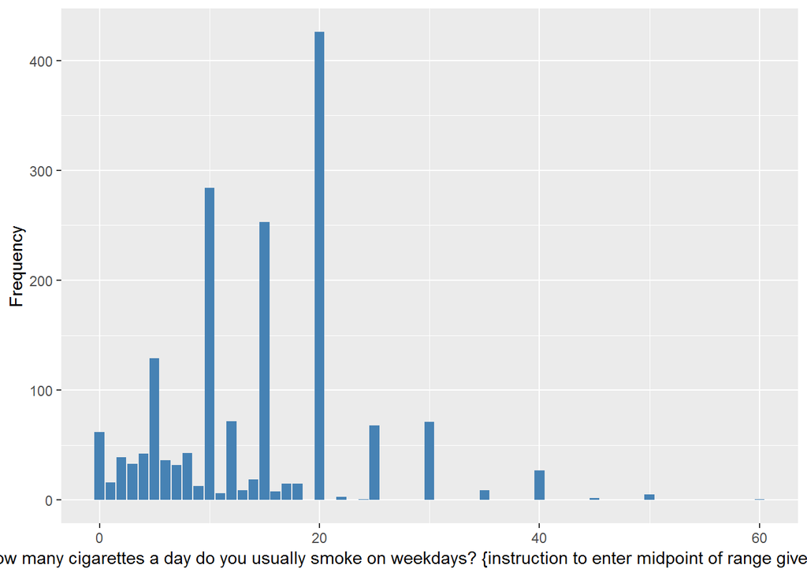

(en) About how many cigarettes a day do you usually smoke on weekends? {instruction to enter midpoint of range given & can~t estimate}

| Sample size | Missing values |
| --- | --- |
| 12099 | 10360 |

Summary

| Min. | 1st Qu. | Median | Mean | 3rd Qu. | Max. |
| --- | --- | --- | --- | --- | --- |
| 0 | 10 | 15 | 14.84 | 20 | 50 |

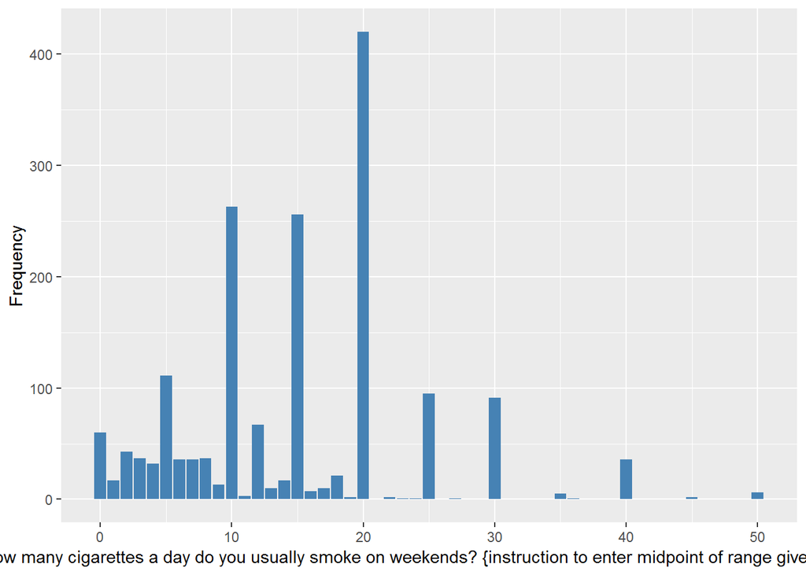

#### 2.1.1.2 Harmonisation algorithm

To compute `n_cigarettes` from the study-specific variable it has to be recoded as follows:

- `heskb*5+heskc*2`
- `-9 into 997`
- `-8 into 998`
- `-1 into 996`

**R script:**

```r
ELSA_ds_w1 <- tibble(id = ELSA_w1$id)
# All individuals have the same missing values for both variables.
ELSA_ds_w1$n_cigarettes <- car::recode((ELSA_w1$heskb * 5 + ELSA_w1$heskc *
    2), "-1*7 = 996;-8*7 = 998;-9*7 = 997 ")
```

#### 2.1.1.3 Statistical description of the new harmonised variable

Number of cigarettes smoked per week

| Sample size | Missing values |
| --- | --- |
| 12099 | 10360 |

Values

|  | No-missings | 991 | 992 | 993 | 994 | 995 | 996 | 997 | 998 | 999 | NA |
| --- | --- | --- | --- | --- | --- | --- | --- | --- | --- | --- | --- |
| Frequency | 1739.00 | 0 | 0 | 0 | 0 | 0 | 10351.00 | 2.00 | 7.00 | 0 | 0 |
| Percentage | 14.37 | 0 | 0 | 0 | 0 | 0 | 85.55 | 0.02 | 0.06 | 0 | 0 |

Summary

| Min. | 1st Qu. | Median | Mean | 3rd Qu. | Max. |
| --- | --- | --- | --- | --- | --- |
| 0 | 63 | 105 | 100.8 | 140 | 400 |

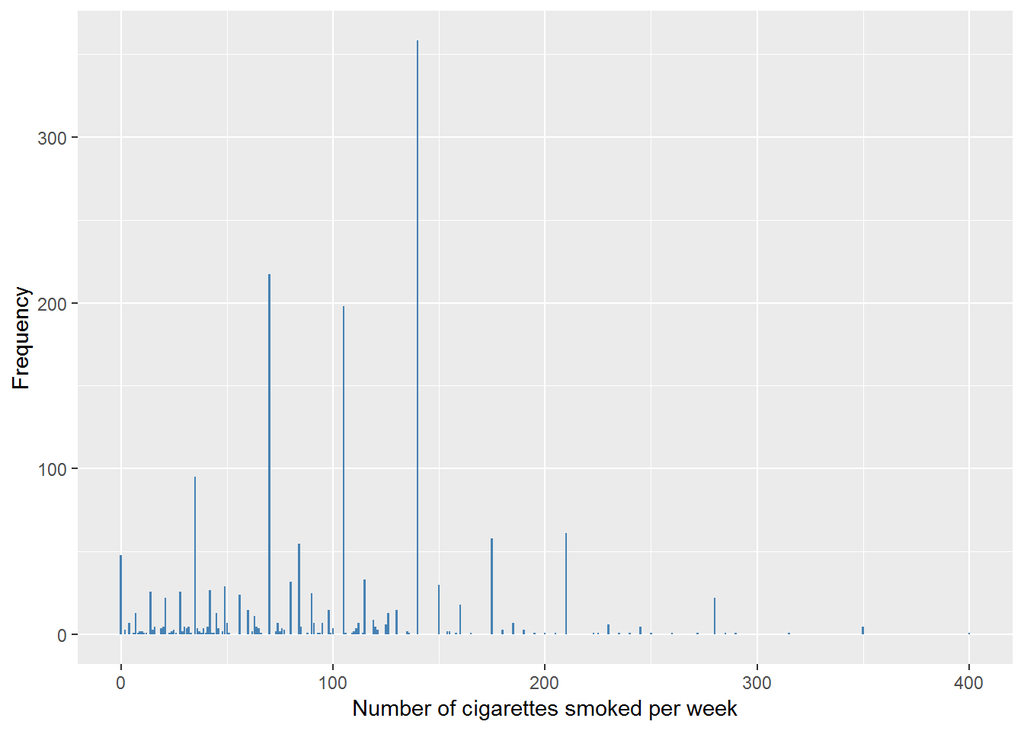

#### 2.1.1.4 Validation

### 2.1.2 Wave 2

#### 2.1.2.1 Study-specific variable description

| **Name** | `HeSkb` | `HeSkc` |
| --- | --- | --- |
| **Label** | `About how many cigarettes a day do you usually smoke on weekdays?` | `About how many cigarettes a day do you usually smoke on weekends?` |
| **Table name** | `wave_2_core_data_v4` | `wave_2_core_data_v4` |
| **Categories:** | `continuous` | `continuous` |
| **Missings:** | `-1 = Not applicable` `-8 = Don't Know` `-9 = Refusal` | `-1 = Not applicable` `-8 = Don't Know` `-9 = Refusal` |
| **Description** |  |  |

(en) Number of cigarettes smoke per weekday

| Sample size | Missing values |
| --- | --- |
| 9432 | 8291 |

Summary

| Min. | 1st Qu. | Median | Mean | 3rd Qu. | Max. |
| --- | --- | --- | --- | --- | --- |
| 0 | 8 | 15 | 13.93 | 20 | 60 |

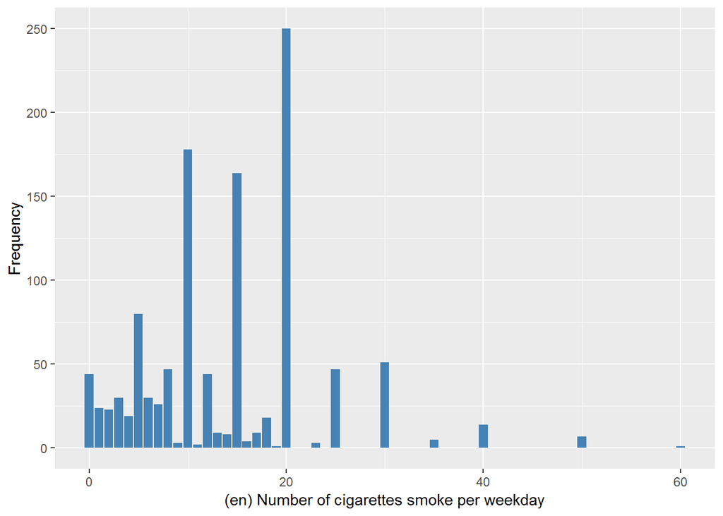

(en) Number of cigarettes smoke per weekend day

| Sample size | Missing values |
| --- | --- |
| 9432 | 8292 |

Summary

| Min. | 1st Qu. | Median | Mean | 3rd Qu. | Max. |
| --- | --- | --- | --- | --- | --- |
| 0 | 8 | 15 | 14.54 | 20 | 60 |

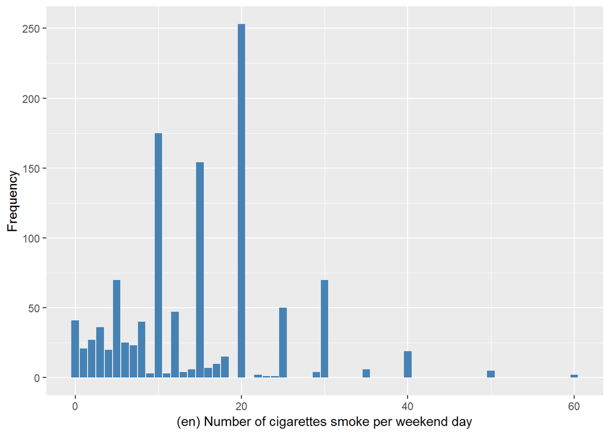

#### 2.1.2.2 Harmonisation algorithm

To compute `n_cigarettes` from the study-specific variable it has to be recoded as follows:

- `HeSkb*5+HeSkc*2`
- `-9 into 997`
- `-8 into 998`
- `-1 into 996`

**R script:**

```r
ELSA_ds_w2 <- tibble(id = ELSA_w2$id)
# All individuals have the same missing values for both variables, but there
# is an individual whose answer to HeSkb is 13 and that has missing value -8
# in HeSkc.
ELSA_ds_w2$n_cigarettes <- car::recode((ELSA_w2$HeSkb * 5 + ELSA_w2$HeSkc *
    2), "-1*7 = 996;-8*7 = 998;-9*7 = 997 ")
ELSA_ds_w2$n_cigarettes[which(ELSA_w2$HeSkc == -8)] <- 998
```

#### 2.1.2.3 Statistical description of the new harmonised variable

Number of cigarettes smoked per week

| Sample size | Missing values |
| --- | --- |
| 9432 | 8292 |

Values

|  | No-missings | 991 | 992 | 993 | 994 | 995 | 996 | 997 | 998 | 999 | NA |
| --- | --- | --- | --- | --- | --- | --- | --- | --- | --- | --- | --- |
| Frequency | 1140.00 | 0 | 0 | 0 | 0 | 0 | 8289.00 | 1.00 | 2.00 | 0 | 0 |
| Percentage | 12.09 | 0 | 0 | 0 | 0 | 0 | 87.88 | 0.01 | 0.02 | 0 | 0 |

Summary

| Min. | 1st Qu. | Median | Mean | 3rd Qu. | Max. |
| --- | --- | --- | --- | --- | --- |
| 0 | 56 | 99.5 | 98.75 | 140 | 370 |

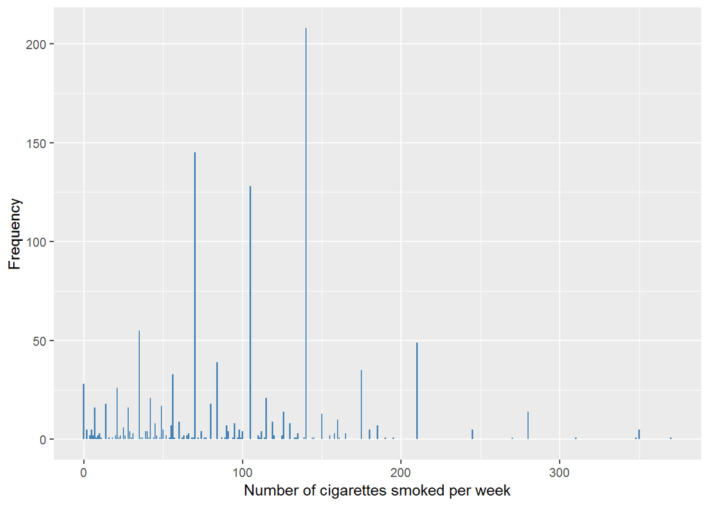

#### 2.1.2.4 Validation

### 2.1.3 Wave 3

#### 2.1.3.1 Study-specific variable description

| **Name** | `heskb` | `heskc` |
| --- | --- | --- |
| **Label** | `About how many cigarettes a day do you usually smoke on weekdays?` | `About how many cigarettes a day do you usually smoke on weekends?` |
| **Table name** | `wave_3_elsa_data_v4` | `wave_3_elsa_data_v4` |
| **Categories:** | `continuous` | `continuous` |
| **Missings:** | `-1 = Not applicable` `-8 = Don't Know` `-9 = Refusal` | `-1 = Not applicable` `-8 = Don't Know` `-9 = Refusal` |
| **Description** |  |  |

(en) Number of cigarettes smoke per weekday

| Sample size | Missing values |
| --- | --- |
| 9771 | 8622 |

Summary

| Min. | 1st Qu. | Median | Mean | 3rd Qu. | Max. |
| --- | --- | --- | --- | --- | --- |
| 0 | 7 | 12 | 13.6 | 20 | 60 |

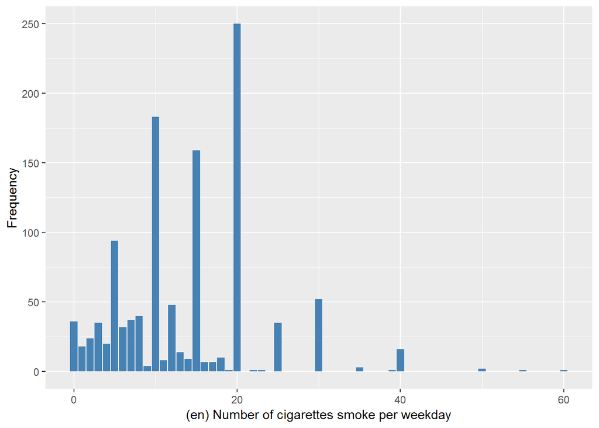

(en) Number of cigarettes smoke per weekend day

| Sample size | Missing values |
| --- | --- |
| 9771 | 8623 |

Summary

| Min. | 1st Qu. | Median | Mean | 3rd Qu. | Max. |
| --- | --- | --- | --- | --- | --- |
| 0 | 8 | 15 | 14.33 | 20 | 60 |

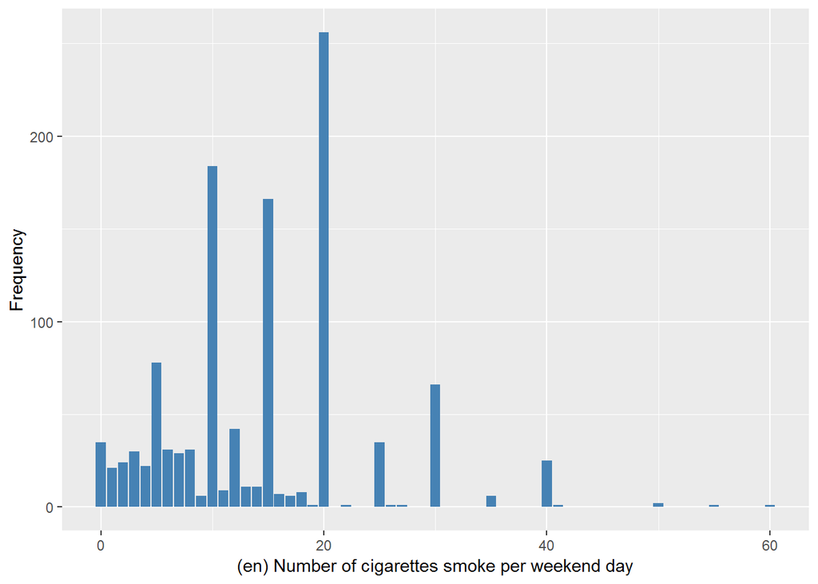

#### 2.1.3.2 Harmonisation algorithm

To compute `n_cigarettes` from the study-specific variable it has to be recoded as follows:

- `heskb*5+heskc*2`
- `-9 into 997`
- `-8 into 998`
- `-1 into 996`

**R script:**

```r
ELSA_ds_w3 <- tibble(id = ELSA_w3$id)
# All individuals have the same missing values for both variables, but there
# is an individual whose answer to heskb is 25 and that has missing value -8
# in heskc.
ELSA_ds_w3$n_cigarettes <- car::recode((ELSA_w3$heskb * 5 + ELSA_w3$heskc *
    2), "-1*7 = 996;-8*7 = 998;-9*7 = 997 ")
ELSA_ds_w3$n_cigarettes[which(ELSA_w3$heskc == -8)] <- 998
```

#### 2.1.3.3 Statistical description of the new harmonised variable

Number of cigarettes smoked per week

| Sample size | Missing values |
| --- | --- |
| 9771 | 8623 |

Values

|  | No-missings | 991 | 992 | 993 | 994 | 995 | 996 | 997 | 998 | 999 | NA |
| --- | --- | --- | --- | --- | --- | --- | --- | --- | --- | --- | --- |
| Frequency | 1148.00 | 0 | 0 | 0 | 0 | 0 | 8620.00 | 1.00 | 2.00 | 0 | 0 |
| Percentage | 11.75 | 0 | 0 | 0 | 0 | 0 | 88.22 | 0.01 | 0.02 | 0 | 0 |

Summary

| Min. | 1st Qu. | Median | Mean | 3rd Qu. | Max. |
| --- | --- | --- | --- | --- | --- |
| 0 | 52.25 | 90 | 96.6 | 140 | 420 |

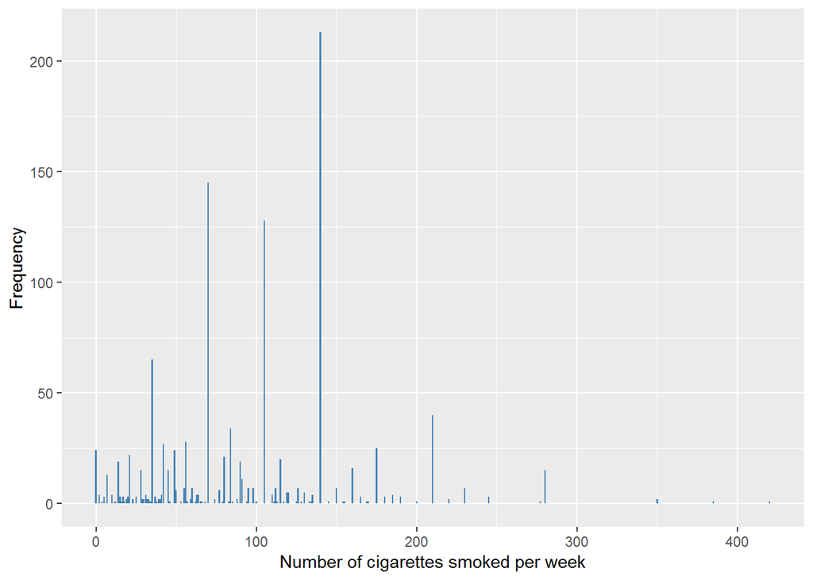

#### 2.1.3.4 Validation

### 2.1.4 Wave 4

#### 2.1.4.1 Study-specific variable description

| **Name** | `heskb` | `heskc` |
| --- | --- | --- |
| **Label** | `About how many cigarettes a day do you usually smoke on weekdays?` | `About how many cigarettes a day do you usually smoke on weekends?` |
| **Table name** | `wave_4_elsa_data_v3` | `wave_4_elsa_data_v3` |
| **Categories:** | `continuous` | `continuous` |
| **Missings:** | `-1 = Not applicable` `-8 = Don't Know` | `-1 = Not applicable` `-8 = Don't Know` |
| **Description** |  |  |

(en) Number of cigarettes smoke per weekday

| Sample size | Missing values |
| --- | --- |
| 11050 | 9911 |

Summary

| Min. | 1st Qu. | Median | Mean | 3rd Qu. | Max. |
| --- | --- | --- | --- | --- | --- |
| 0 | 8 | 13 | 13.96 | 20 | 100 |

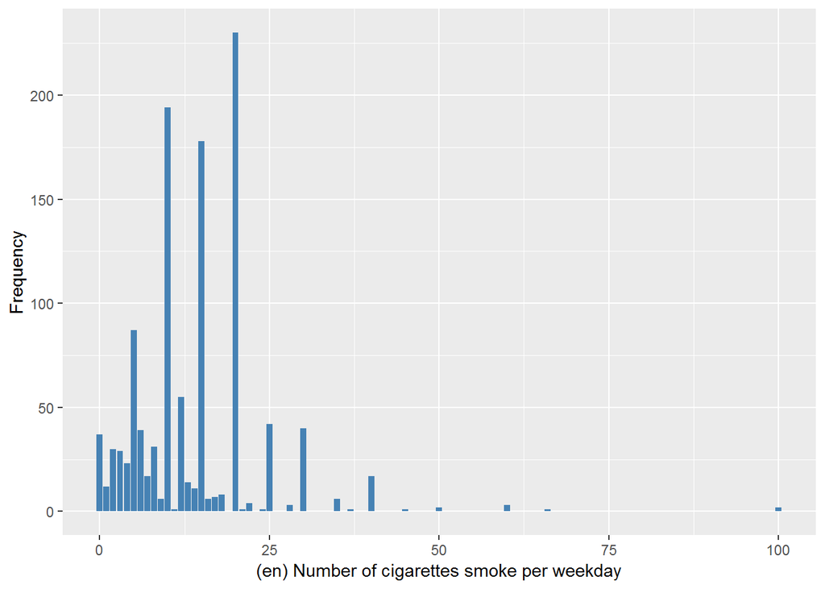

(en) Number of cigarettes smoke per weekend day

| Sample size | Missing values |
| --- | --- |
| 11050 | 9911 |

Summary

| Min. | 1st Qu. | Median | Mean | 3rd Qu. | Max. |
| --- | --- | --- | --- | --- | --- |
| 0 | 8 | 15 | 14.57 | 20 | 140 |

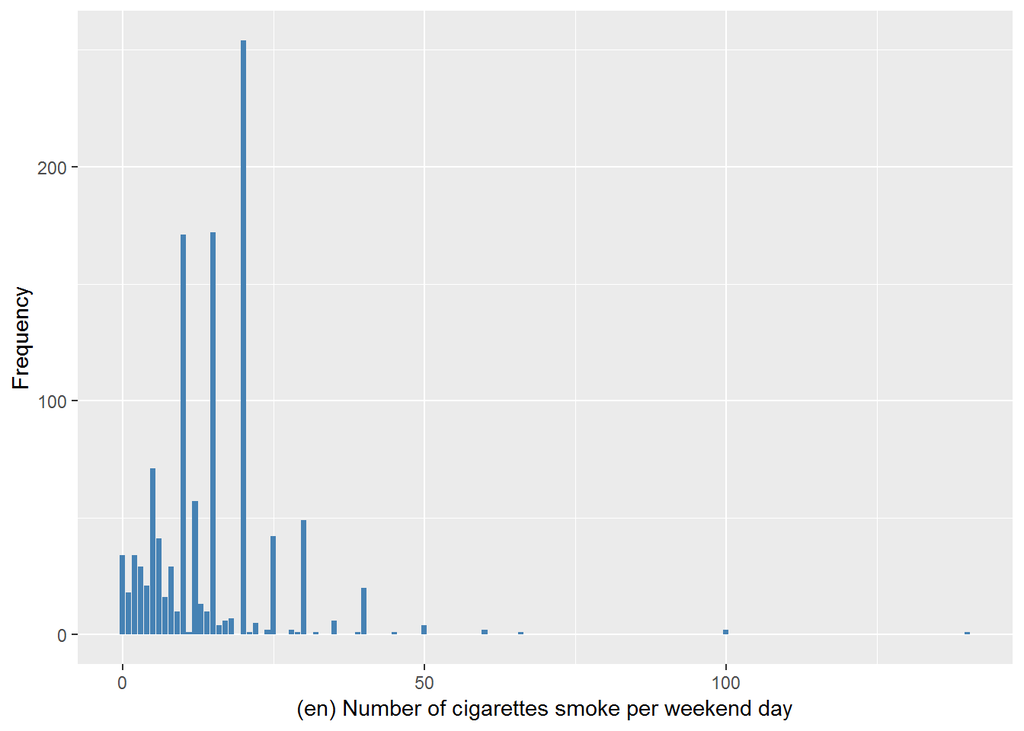

#### 2.1.4.2 Harmonisation algorithm

To compute `n_cigarettes` from the study-specific variable it has to be recoded as follows:

- `heskb*5+heskc*2`
- `-8 into 998`
- `-1 into 996`

**R script:**

```r
ELSA_ds_w4 <- tibble(id = ELSA_w4$id)
# All individuals have the same missing values for both variables.
ELSA_ds_w4$n_cigarettes <- car::recode((ELSA_w4$heskb * 5 + ELSA_w4$heskc *
    2), "-1*7 = 996;-8*7 = 998 ")
```

#### 2.1.4.3 Statistical description of the new harmonised variable

Number of cigarettes smoked per week

| Sample size | Missing values |
| --- | --- |
| 11050 | 9911 |

Values

|  | No-missings | 991 | 992 | 993 | 994 | 995 | 996 | 997 | 998 | 999 | NA |
| --- | --- | --- | --- | --- | --- | --- | --- | --- | --- | --- | --- |
| Frequency | 1139.00 | 0 | 0 | 0 | 0 | 0 | 9909.00 | 0 | 2.00 | 0 | 0 |
| Percentage | 10.31 | 0 | 0 | 0 | 0 | 0 | 89.67 | 0 | 0.02 | 0 | 0 |

Summary

| Min. | 1st Qu. | Median | Mean | 3rd Qu. | Max. |
| --- | --- | --- | --- | --- | --- |
| 0 | 56 | 95 | 98.94 | 140 | 700 |

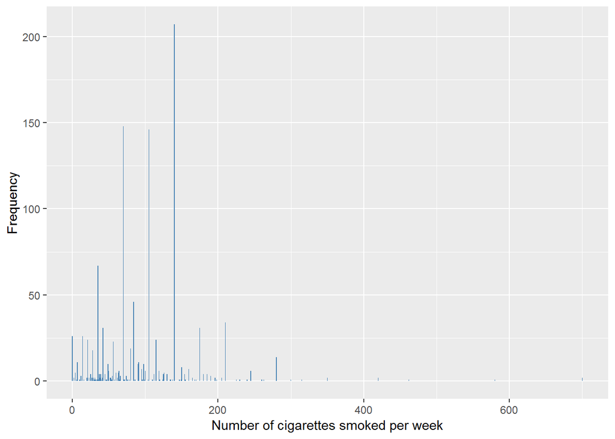

#### 2.1.4.4 Validation

### 2.1.5 Wave 5

#### 2.1.5.1 Study-specific variable description

| **Name** | `heskb` | `heskc` |
| --- | --- | --- |
| **Label** | `About how many cigarettes a day do you usually smoke on weekdays?` | `About how many cigarettes a day do you usually smoke on weekends?` |
| **Table name** | `wave_5_elsa_data_v4` | `wave_5_elsa_data_v4` |
| **Categories:** | `continuous` | `continuous` |
| **Missings:** | `-1 = Not applicable` `-8 = Don't Know` `-9 = Refusal` | `-1 = Not applicable` `-8 = Don't Know` `-9 = Refusal` |
| **Description** |  |  |

(en) Number of cigarettes smoke per weekday

| Sample size | Missing values |
| --- | --- |
| 10274 | 9332 |

Summary

| Min. | 1st Qu. | Median | Mean | 3rd Qu. | Max. |
| --- | --- | --- | --- | --- | --- |
| 0 | 7 | 12 | 13.67 | 20 | 150 |

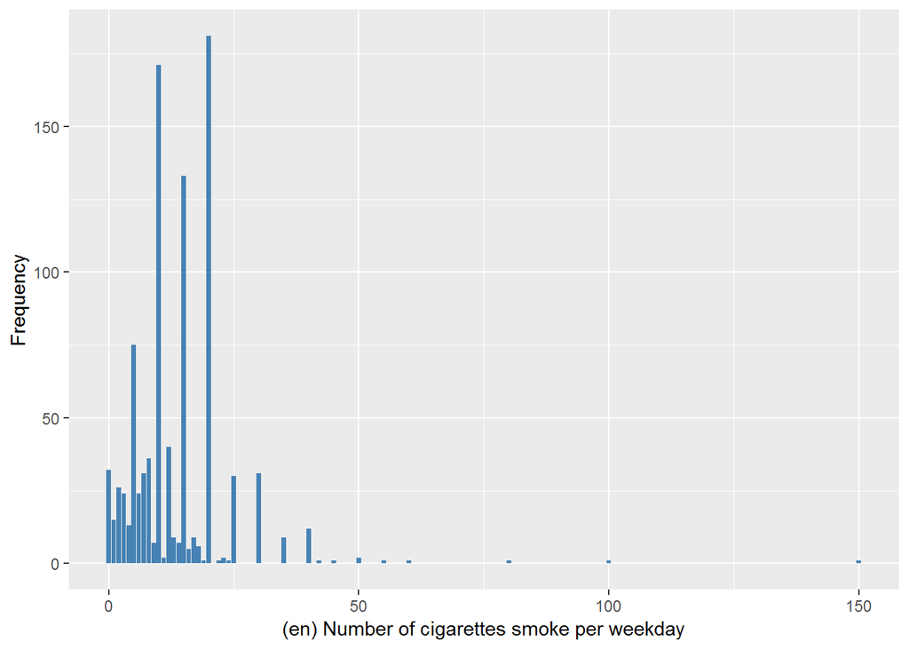

(en) Number of cigarettes smoke per weekend day

| Sample size | Missing values |
| --- | --- |
| 10274 | 9332 |

Summary

| Min. | 1st Qu. | Median | Mean | 3rd Qu. | Max. |
| --- | --- | --- | --- | --- | --- |
| 0 | 8 | 13 | 13.96 | 20 | 80 |

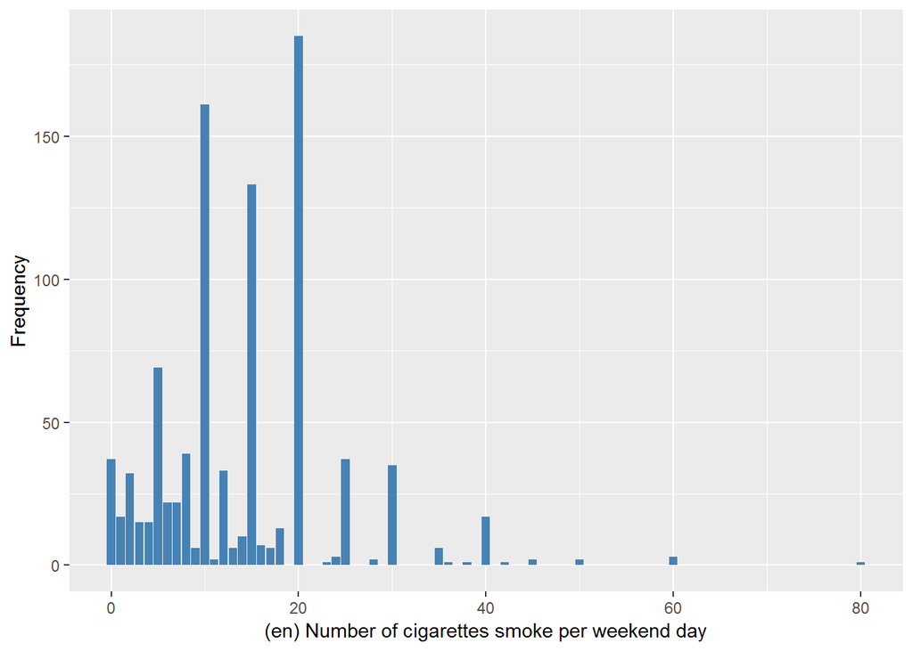

#### 2.1.5.2 Harmonisation algorithm

To compute `n_cigarettes` from the study-specific variable it has to be recoded as follows:

- `heskb*5+heskc*2`
- `-9 into 997`
- `-8 into 998`
- `-1 into 996`

**R script:**

```r
ELSA_ds_w5 <- tibble(id = ELSA_w5$id)
# All individuals have the same missing values for both variables.
ELSA_ds_w5$n_cigarettes <- car::recode((ELSA_w5$heskb * 5 + ELSA_w5$heskc *
    2), "-1*7 = 996;-8*7 = 998;-9*7 = 997 ")
```

#### 2.1.5.3 Statistical description of the new harmonised variable

Number of cigarettes smoked per week

| Sample size | Missing values |
| --- | --- |
| 10274 | 9332 |

Values

|  | No-missings | 991 | 992 | 993 | 994 | 995 | 996 | 997 | 998 | 999 | NA |
| --- | --- | --- | --- | --- | --- | --- | --- | --- | --- | --- | --- |
| Frequency | 942.00 | 0 | 0 | 0 | 0 | 0 | 9329.0 | 2.00 | 1.00 | 0 | 0 |
| Percentage | 9.17 | 0 | 0 | 0 | 0 | 0 | 90.8 | 0.02 | 0.01 | 0 | 0 |

Summary

| Min. | 1st Qu. | Median | Mean | 3rd Qu. | Max. |
| --- | --- | --- | --- | --- | --- |
| 0 | 50.5 | 84 | 96.29 | 140 | 870 |

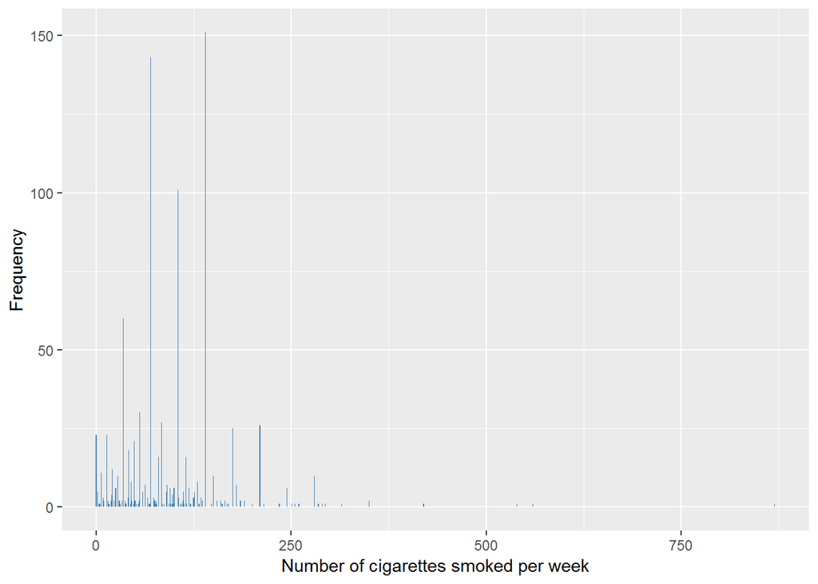

#### 2.1.5.4 Validation

### 2.1.6 Wave 6

#### 2.1.6.1 Study-specific variable description

| **Name** | `HeSkb` | `HeSkc` |
| --- | --- | --- |
| **Label** | `About how many cigarettes a day do you usually smoke on weekdays?` | `About how many cigarettes a day do you usually smoke on weekends?` |
| **Table name** | `wave_6_elsa_data_v2` | `wave_6_elsa_data_v2` |
| **Categories:** | `continuous` | `continuous` |
| **Missings:** | `-1 = Not applicable` `-8 = Don't Know` | `-1 = Not applicable` `-8 = Don't Know` |
| **Description** |  |  |

(en) Number of cigarettes smoke per weekday

| Sample size | Missing values |
| --- | --- |
| 10601 | 9698 |

Summary

| Min. | 1st Qu. | Median | Mean | 3rd Qu. | Max. |
| --- | --- | --- | --- | --- | --- |
| 0 | 7 | 12 | 13.48 | 20 | 80 |

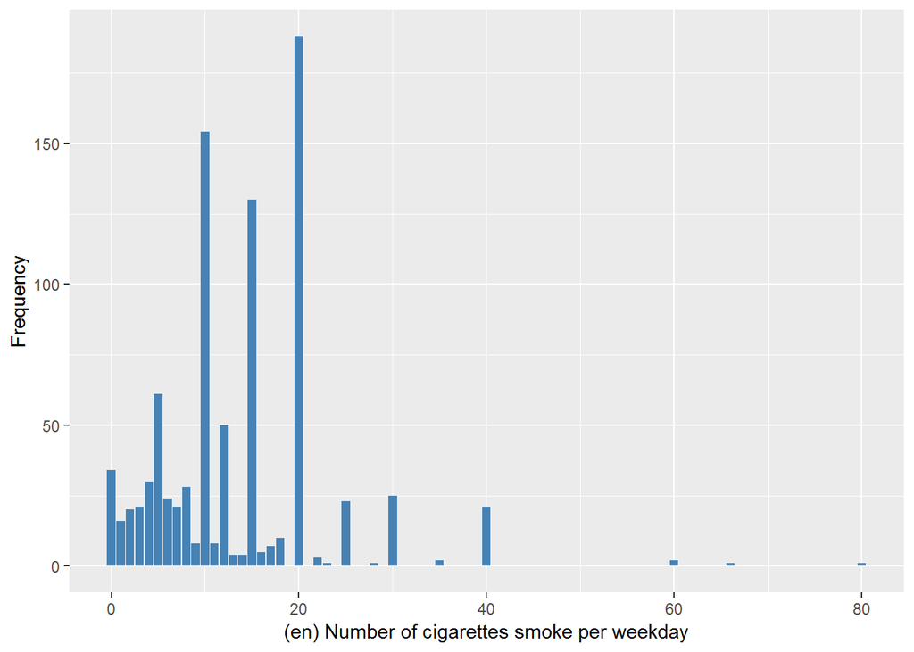

(en) Number of cigarettes smoke per weekend day

| Sample size | Missing values |
| --- | --- |
| 10601 | 9697 |

Summary

| Min. | 1st Qu. | Median | Mean | 3rd Qu. | Max. |
| --- | --- | --- | --- | --- | --- |
| 0 | 8 | 13 | 13.9 | 20 | 66 |

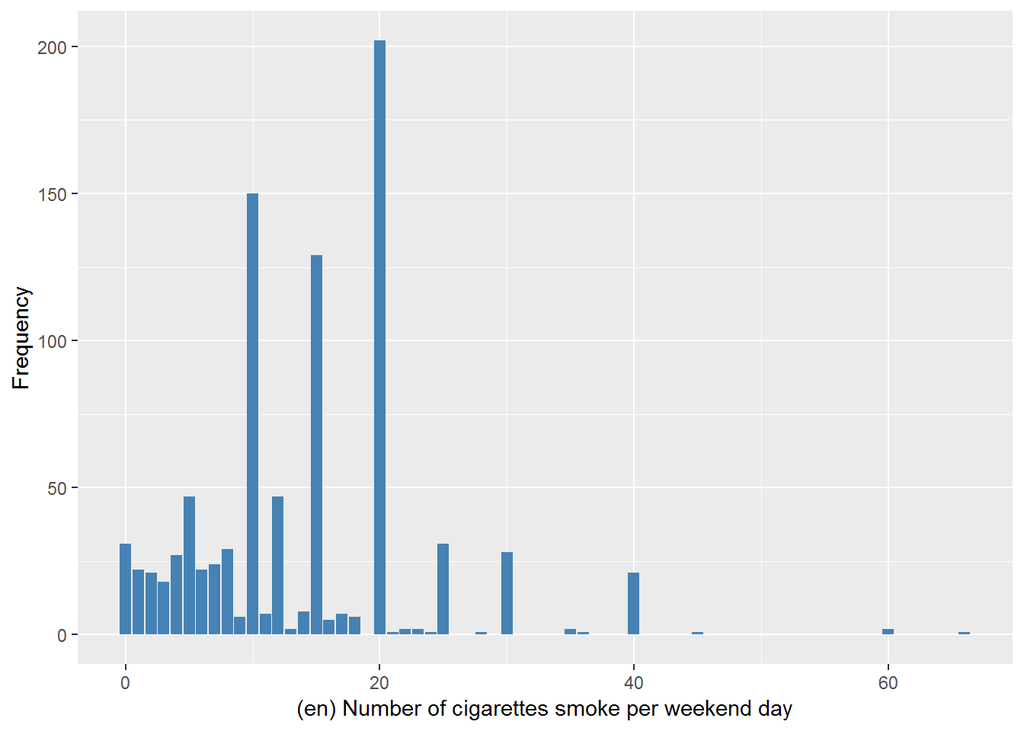

#### 2.1.6.2 Harmonisation algorithm

To compute `n_cigarettes` from the study-specific variable it has to be recoded as follows:

- `HeSkb*5+HeSkc*2`
- `-8 into 998`
- `-1 into 996`

**R script:**

```r
ELSA_ds_w6 <- tibble(id = ELSA_w6$id)
# All individuals have the same missing values for both variables, but there
# is an individual whose answer to HeSkc is 0 and that has missing value -8
# in HeSkb.
ELSA_ds_w6$n_cigarettes <- car::recode((ELSA_w6$HeSkb * 5 + ELSA_w6$HeSkc *
    2), "-1*7 = 996;-8*7 = 998;-9*7 = 997; -8*5 = 998 ")
```

#### 2.1.6.3 Statistical description of the new harmonised variable

Number of cigarettes smoked per week

| Sample size | Missing values |
| --- | --- |
| 10601 | 9698 |

Values

|  | No-missings | 991 | 992 | 993 | 994 | 995 | 996 | 997 | 998 | 999 | NA |
| --- | --- | --- | --- | --- | --- | --- | --- | --- | --- | --- | --- |
| Frequency | 903.00 | 0 | 0 | 0 | 0 | 0 | 9695.00 | 0 | 3.00 | 0 | 0 |
| Percentage | 8.52 | 0 | 0 | 0 | 0 | 0 | 91.45 | 0 | 0.03 | 0 | 0 |

Summary

| Min. | 1st Qu. | Median | Mean | 3rd Qu. | Max. |
| --- | --- | --- | --- | --- | --- |
| 0 | 56 | 84 | 95.23 | 140 | 462 |

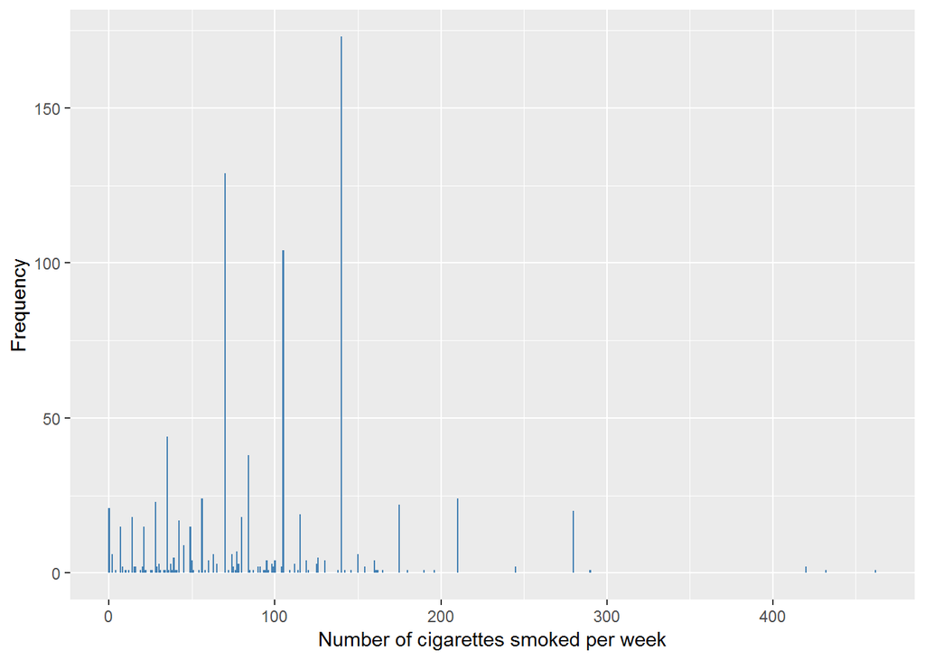

#### 2.1.6.4 Validation

### 2.1.7 Wave 7

#### 2.1.7.1 Study-specific variable description

| **Name** | `HeSkb` | `HeSkc` |
| --- | --- | --- |
| **Label** | `Number of cigarettes smoke per weekday` | `Number of cigarettes smoke per weekend day` |
| **Table name** | `wave_7_elsa_data` | `wave_7_elsa_data` |
| **Categories:** | `continuous` | `continuous` |
| **Missings:** | `-1 = Not applicable` `-8 = Don't Know` `-9 = Refusal` | `-1 = Not applicable` `-8 = Don't Know` `-9 = Refusal` |
| **Description** |  |  |

(en) Number of cigarettes smoke per weekday

| Sample size | Missing values |
| --- | --- |
| 9666 | 8949 |

Summary

| Min. | 1st Qu. | Median | Mean | 3rd Qu. | Max. |
| --- | --- | --- | --- | --- | --- |
| 0 | 6 | 12 | 12.88 | 20 | 100 |

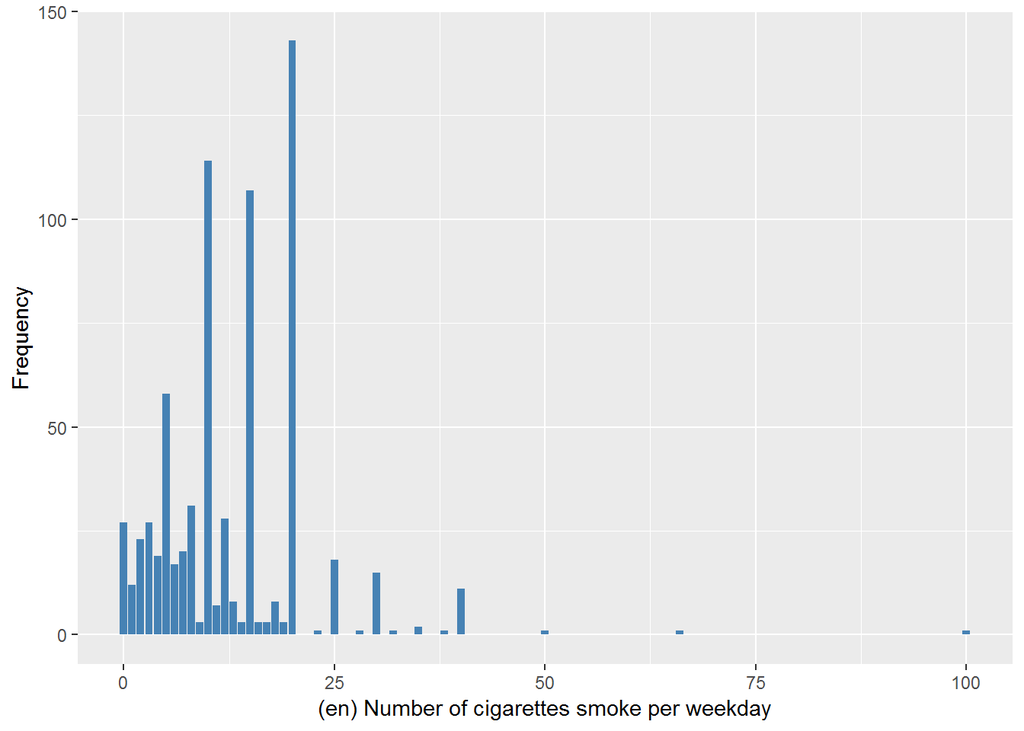

(en) Number of cigarettes smoke per weekend day

| Sample size | Missing values |
| --- | --- |
| 9666 | 8949 |

Summary

| Min. | 1st Qu. | Median | Mean | 3rd Qu. | Max. |
| --- | --- | --- | --- | --- | --- |
| 0 | 7 | 12 | 13.27 | 20 | 100 |

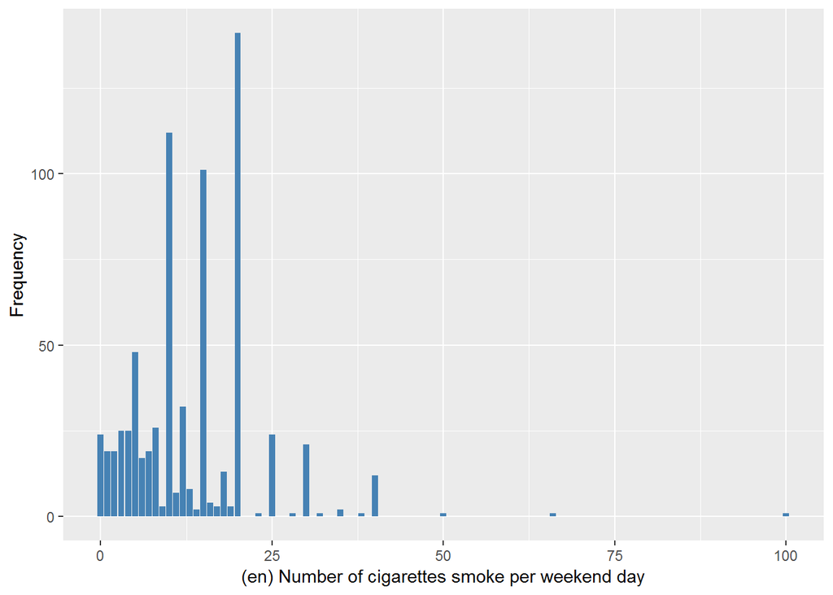

#### 2.1.7.2 Harmonisation algorithm

To compute `n_cigarettes` from the study-specific variable it has to be recoded as follows:

- `HeSkb*5+HeSkc*2`
- `-9 into 997`
- `-8 into 998`
- `-1 into 996`

**R script:**

```r
ELSA_ds_w7 <- tibble(id = ELSA_w7$id)
# All individuals have the same missing values for both variables, but there
# is an individual whose answer to HeSkb is 0 and that has missing value -8
# in HeSkc, and another whose answer to HeSkc is 10 and that has missing
# value -8 in HeSkb
ELSA_ds_w7$n_cigarettes <- car::recode((ELSA_w7$HeSkb * 5 + ELSA_w7$HeSkc *
    2), "-1*7 = 996;-8*7 = 998;-9*7 = 997 ; -8*2 = 998")
ELSA_ds_w7$n_cigarettes[which(ELSA_w7$HeSkb == -8)] <- 998
```

#### 2.1.7.3 Statistical description of the new harmonised variable

Number of cigarettes smoked per week

| Sample size | Missing values |
| --- | --- |
| 9666 | 8950 |

Values

|  | No-missings | 991 | 992 | 993 | 994 | 995 | 996 | 997 | 998 | 999 | NA |
| --- | --- | --- | --- | --- | --- | --- | --- | --- | --- | --- | --- |
| Frequency | 716.00 | 0 | 0 | 0 | 0 | 0 | 8946.00 | 1.00 | 3.00 | 0 | 0 |
| Percentage | 7.41 | 0 | 0 | 0 | 0 | 0 | 92.55 | 0.01 | 0.03 | 0 | 0 |

Summary

| Min. | 1st Qu. | Median | Mean | 3rd Qu. | Max. |
| --- | --- | --- | --- | --- | --- |
| 0 | 48.75 | 84 | 91.02 | 140 | 700 |

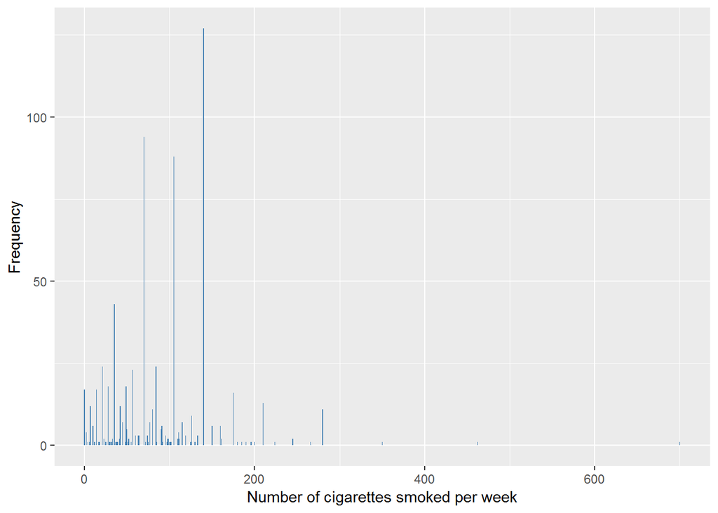

#### 2.1.7.4 Validation

## 2.2 Summary of descriptive statistics of the harmonised variable accross populations and waves

Number of cigarettes smoked per week

| n_cigarettes | W1 | W2 | W3 | W4 | W5 | W6 | W7 |
| --- | --- | --- | --- | --- | --- | --- | --- |
| Min. | 0 | 0 | 0 | 0 | 0 | 0 | 0 |
| 1st Qu. | 63 | 56 | 52.25 | 56 | 50.5 | 56 | 48.75 |
| Median | 105 | 99.5 | 90 | 95 | 84 | 84 | 84 |
| Mean | 100.8 | 98.75 | 96.6 | 98.94 | 96.29 | 95.23 | 91.02 |
| 3rd Qu. | 140 | 140 | 140 | 140 | 140 | 140 | 140 |
| Max. | 400 | 370 | 420 | 700 | 870 | 462 | 700 |
| No-missings | 1739 | 1140 | 1148 | 1139 | 942 | 903 | 716 |
| 991 | 0 | 0 | 0 | 0 | 0 | 0 | 0 |
| 992 | 0 | 0 | 0 | 0 | 0 | 0 | 0 |
| 993 | 0 | 0 | 0 | 0 | 0 | 0 | 0 |
| 994 | 0 | 0 | 0 | 0 | 0 | 0 | 0 |
| 995 | 0 | 0 | 0 | 0 | 0 | 0 | 0 |
| 996 | 10351 | 8289 | 8620 | 9909 | 9329 | 9695 | 8946 |
| 997 | 2 | 1 | 1 | 0 | 2 | 0 | 1 |
| 998 | 7 | 2 | 2 | 2 | 1 | 3 | 3 |
| 999 | 0 | 0 | 0 | 0 | 0 | 0 | 0 |
| NA | 0 | 0 | 0 | 0 | 0 | 0 | 0 |
| sample size | 12099 | 9432 | 9771 | 11050 | 10274 | 10601 | 9666 |

# 3 Quality estimation